# Painel IPCA — Inflação Brasileira

Análise mensal com dados do BCB e IBGE

Autor

Raimundo Casé — economista

Data de Publicação

12 de novembro de 2026

## 1 Introdução

O **Índice Nacional de Preços ao Consumidor Amplo (IPCA)** é o indicador oficial de inflação do Brasil, medido mensalmente pelo IBGE. Calculado com base em uma cesta de consumo de famílias com renda entre 1 e 40 salários mínimos nas principais regiões metropolitanas do país, o IPCA é a referência adotada pelo Banco Central na condução da política monetária pelo regime de metas de inflação, em vigor desde 1999.

A interpretação do IPCA exige múltiplas lentes temporais. A variação mensal revela o pulso imediato dos preços; o acumulado em doze meses é o horizonte pelo qual o Conselho Monetário Nacional (CMN) avalia o cumprimento da meta; o acumulado no ano captura a trajetória corrente; e a decomposição por grupos de despesa — Alimentação e Bebidas, Habitação, Transportes, entre outros — permite identificar de onde vem a pressão inflacionária.

Este relatório vai além da leitura do índice cheio. Depois do panorama mensal, ele desce ao nível do **subitem** para separar o que de fato moveu o índice daquilo que apenas variou muito; isola o **miolo da inflação** pelos núcleos acompanhados pelo Banco Central, pela natureza dos bens e pela difusão; confronta o resultado com o que o mercado **projetava**; e verifica quanto do número nacional é choque **local**. São dimensões que a divulgação oficial do IBGE não cobre — e são elas que dizem se um resultado benigno significa desinflação ou apenas um alívio passageiro.

Os dados mais recentes disponíveis são de **outubro de 2026**. Naquele mês, o IPCA registrou variação de **0.14%**, enquanto o acumulado em doze meses alcançou **4.63%** e o acumulado no ano chegou a **4.10%**. Ao longo das seções seguintes, esses números são contextualizados frente à meta vigente de **3.00%** (±1,5 p.p.) e ao comportamento histórico dos grupos de despesa.

## 2 Panorama Mensal

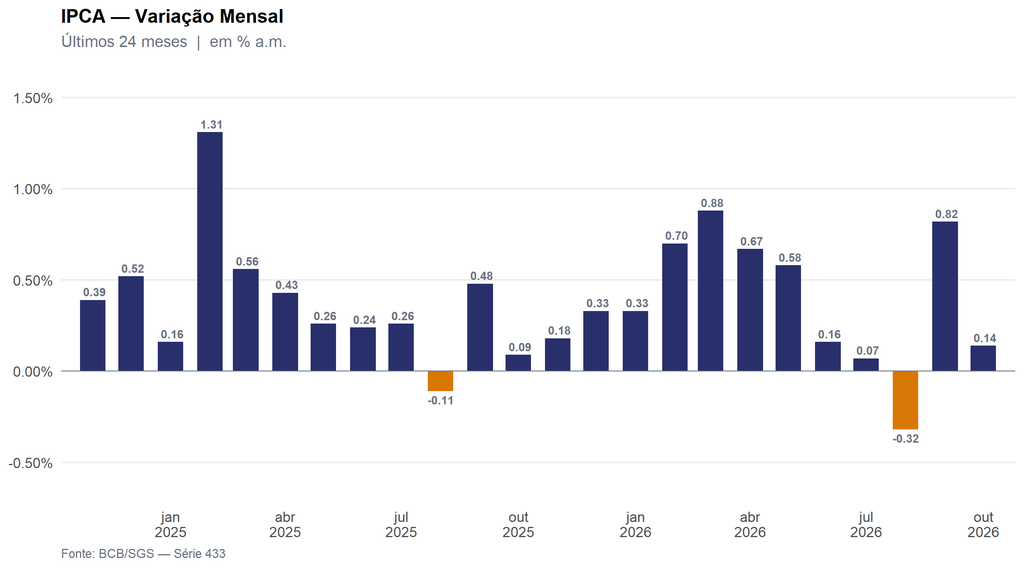

Figura 1: IPCA — variação mensal (últimos 24 meses, referência out/2026)

Em **out/2026**, o IPCA variou **0.14%**, resultado inferior ao registrado em set/2026 (0.82%), uma diferença de **-0.68 p.p.**. O gráfico acima exibe as barras mensais dos últimos 24 meses em escala truncada para facilitar a leitura das variações, que em geral oscilam em frações de ponto percentual. Barras em azul-marinho indicam meses de inflação positiva; barras em âmbar, deflação.

A leitura isolada do mês corrente, embora relevante para acompanhar o ritmo de curto prazo, pode ser enganosa quando o IPCA apresenta forte componente sazonal — como ocorre tipicamente em março (reajuste de mensalidades escolares) e nos meses de energia elétrica. Por isso, a seção seguinte amplia o horizonte para o acumulado em 12 meses, que suaviza esses efeitos e oferece a visão sobre a qual o Banco Central calibra a taxa Selic.

## 3 Acumulado em 12 Meses e Meta

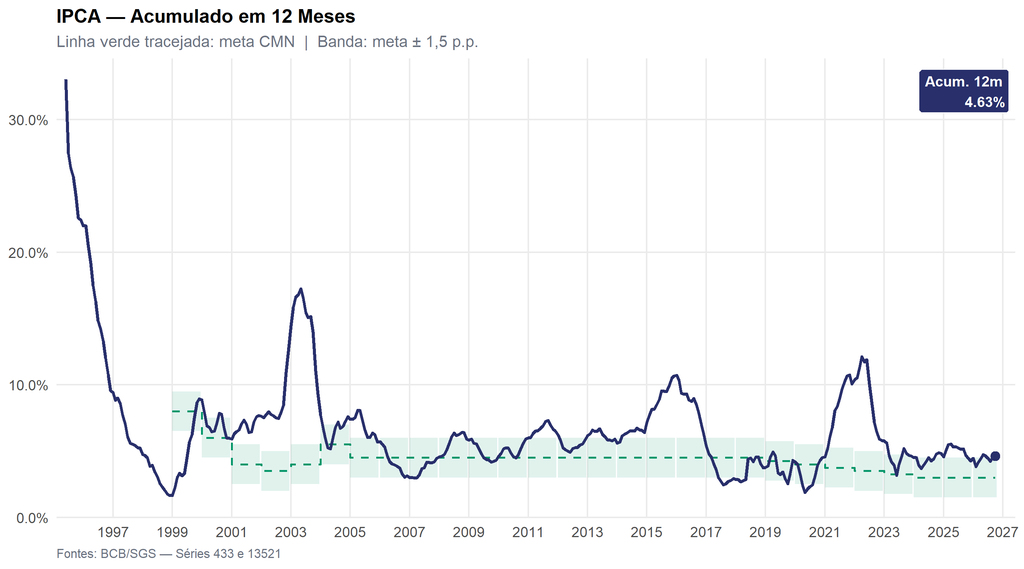

Figura 2: IPCA acumulado em 12 meses e meta do CMN com banda de tolerância (±1,5 p.p.)

O acumulado em doze meses atingiu **4.63%** em out/2026. A meta fixada pelo CMN para 2026 é de **3.00%**, com intervalo de tolerância entre **1.50%** e **4.50%**. O IPCA 12m está, portanto, **fora** da banda de tolerância. A faixa verde translúcida no gráfico marca essa banda; a linha tracejada, a meta central, que pode mudar de patamar ano a ano conforme as deliberações do CMN.

A série histórica evidencia os episódios em que o IPCA ultrapassou o teto — em particular o biênio 2021–2022, marcado pelos choques de energia, câmbio e commodities no pós-pandemia — e a subsequente desinflação que trouxe o índice de volta à vizinhança da meta. O gráfico apresenta a meta em degraus anuais (`geom_step`), sem interpolar entre valores de anos consecutivos, o que preserva a fidelidade à deliberação oficial: a meta é válida para o ano inteiro, não varia mês a mês.

A caixa no canto superior direito exibe o último valor disponível do IPCA 12m, facilitando a leitura imediata sem necessidade de inspecionar o eixo vertical. Esse recurso é especialmente útil quando o relatório é consultado rapidamente, como em reuniões do Copom ou apresentações de estratégia.

## 4 Sazonalidade

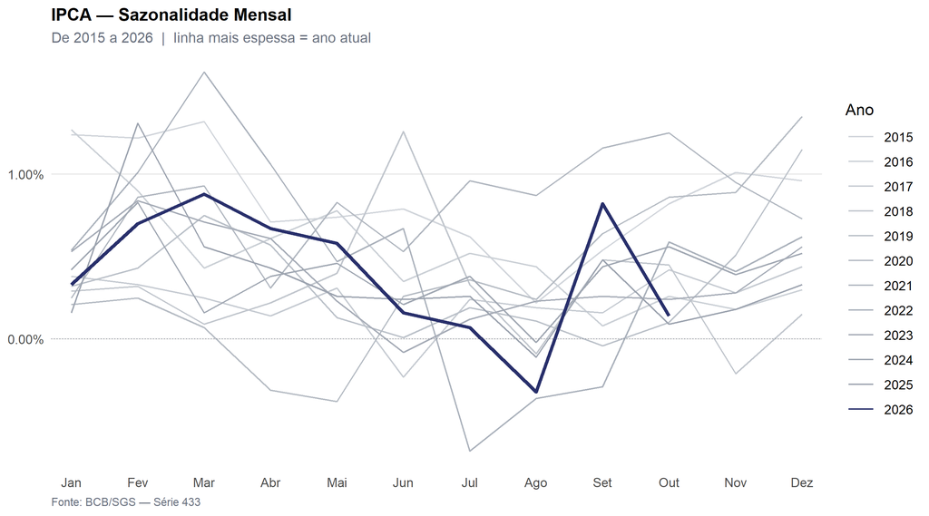

Figura 3: IPCA — sazonalidade mensal por ano (2015–2026)

O gráfico sazonal sobrepõe a trajetória mensal de cada ano — cada linha corresponde a um ano, o ano 2026 destacado em azul com traço mais espesso e os demais em gradiente de cinza. Esse formato permite identificar rapidamente se o padrão do ano corrente se assemelha ao de anos anteriores ou se apresenta desvio significativo, e em qual mês a divergência se manifesta.

Historicamente, o primeiro trimestre concentra as leituras mais elevadas, por conta do reajuste de mensalidades escolares (março), de tarifas de planos de saúde e de itens de alimentação com sazonalidade agrícola. O segundo semestre costuma apresentar alívio relativo, especialmente entre julho e setembro, antes de nova pressão típica de dezembro em itens como vestuário e lazer. Entender esse padrão ajuda a separar o componente sazonal do componente tendencial, um insumo fundamental para modelos de inflação no atacado e para projeções de curto prazo.

A comparação visual entre anos revela também ciclos de política monetária: em anos de aperto (Selic em alta), a linha do IPCA mensal tende a ficar abaixo da média histórica especialmente nos meses de maior inércia; em anos de afrouxamento ou de choques externos, a sazonalidade habitual pode ser amplificada ou invertida.

## 5 Contribuições por Grupo

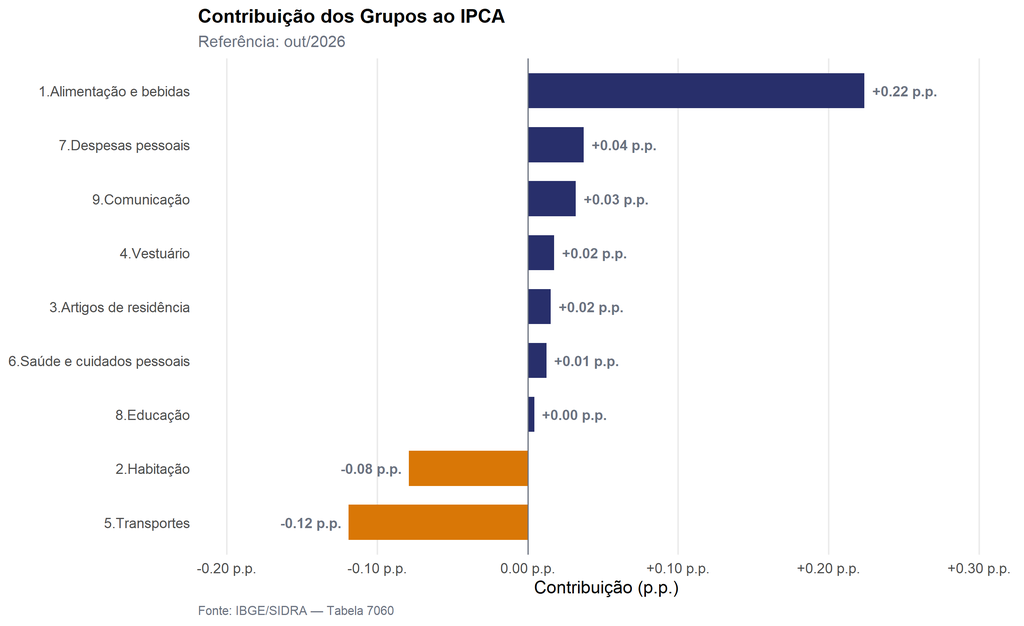

Figura 4: Contribuição ao IPCA por grupo de despesa — out/2026

Tabela 1: Contribuições e pesos por grupo — out/2026

| Grupo | Variação (% a.m.) | Peso (p.p.) | Contribuição (p.p.) |
| --- | --- | --- | --- |
| 1.Alimentação e bebidas | 1.04 | 21.51 | 0.2237 |
| 7.Despesas pessoais | 0.36 | 10.35 | 0.0373 |
| 9.Comunicação | 0.71 | 4.50 | 0.0320 |
| 4.Vestuário | 0.38 | 4.61 | 0.0175 |
| 3.Artigos de residência | 0.44 | 3.47 | 0.0152 |
| 6.Saúde e cuidados pessoais | 0.09 | 13.74 | 0.0124 |
| 8.Educação | 0.07 | 6.16 | 0.0043 |
| 2.Habitação | -0.51 | 15.49 | -0.0790 |
| 5.Transportes | -0.59 | 20.17 | -0.1190 |

Em out/2026, o grupo com **maior contribuição positiva** ao IPCA foi **1.Alimentação e bebidas** (+0.22 p.p.), enquanto **5.Transportes** registrou a **menor contribuição** (-0.12 p.p.).

**NotaVerificação de consistência — out/2026**

Soma das contribuições dos nove grupos: **0.14 p.p.**, contra variação de **0.14%** no índice cheio — desvio de 0.004 p.p. Soma dos pesos: **100.00** (esperado 100, desvio de 0.000). Ambos dentro da tolerância; os dados da API estão consistentes.

## 6 Itens de Maior Impacto

A tabela de grupos responde *onde* a inflação ocorreu, mas não *o que* a produziu. O IPCA é apurado em 377 subitens, e o ranking que a imprensa costuma reproduzir — o das maiores variações — é enganoso: um subitem pode subir 20% e mover o índice em três centésimos, enquanto outro sobe 2% e move o dobro, por pesar muito mais na cesta.

O gráfico abaixo ordena os subitens pela **contribuição em pontos percentuais**, não pela variação. Cada barra traz os dois números, para que a diferença entre “subiu muito” e “pesou muito” fique explícita.

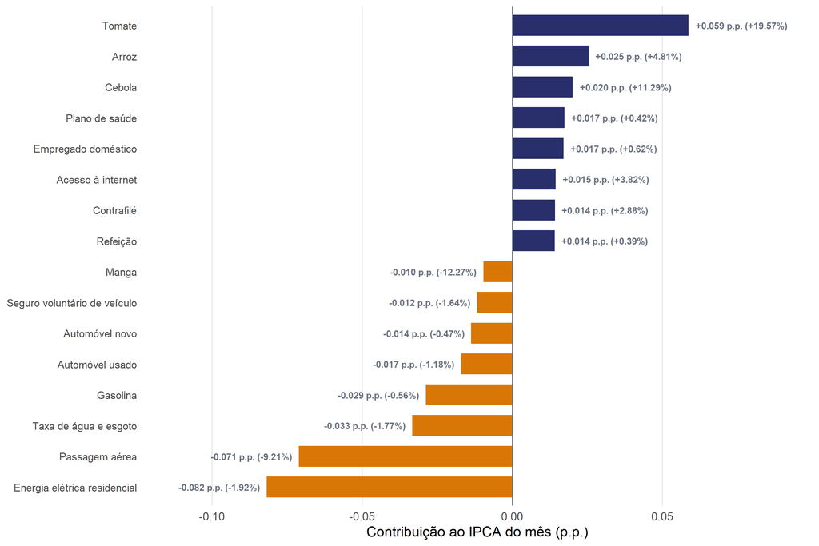

Figura 5: Subitens de maior impacto no IPCA — out/2026

Em out/2026, a maior pressão de alta veio de **Tomate**, que variou 19.57% e contribuiu com +0.059 p.p.. No sentido oposto, **Energia elétrica residencial** foi o maior alívio: -1.92% de variação e -0.082 p.p. de contribuição.

Vale notar a assimetria entre os dois rankings. Itens de alta variação costumam ser alimentos *in natura*, sujeitos a safra e clima, com pesos pequenos e reversão rápida. Já os alívios de maior impacto tendem a vir de itens de peso elevado e preço administrado ou semiadministrado — energia, combustíveis, tarifas —, cuja queda é decidida em reajuste e não em mercado. Essa distinção importa para projeção: o choque de alimento tende a se desfazer sozinho; o alívio tarifário, não se repete.

## 7 Alimentação: Dentro e Fora do Domicílio

A divisão do grupo Alimentação em dois subgrupos separa fenômenos que só por coincidência andam juntos. A **alimentação no domicílio** responde a safra, clima, câmbio e frete — é volátil e reverte. A **alimentação fora do domicílio** é essencialmente serviço: responde a salários, aluguel e energia, tem forte inércia e quase nunca cai.

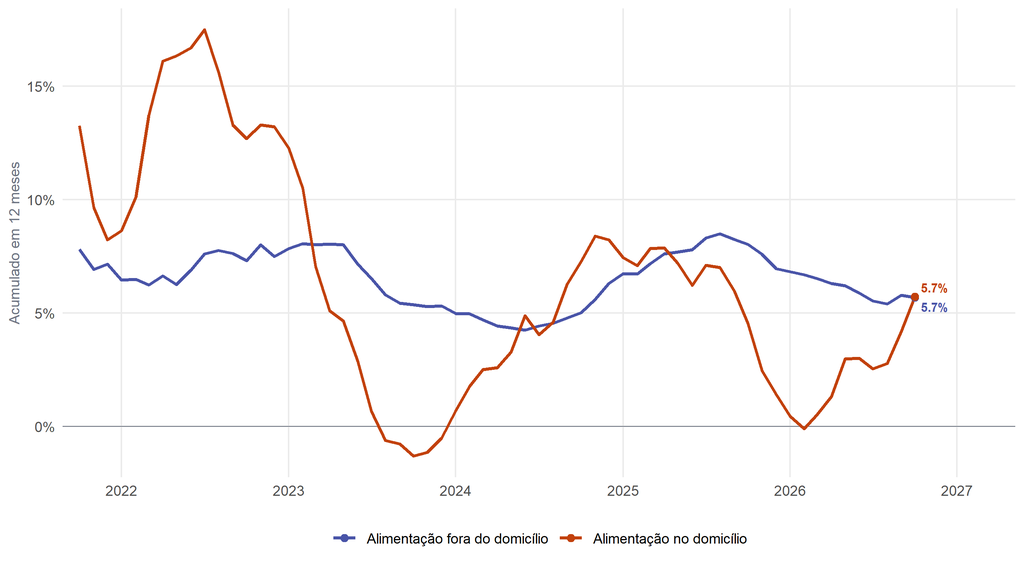

Figura 6: Alimentação dentro e fora do domicílio — acumulado em 12 meses

Em out/2026, a alimentação no domicílio variou **1.31%** e a de fora do domicílio, **0.36%**. No acumulado em 12 meses, estão em 5.72% e 5.68%, respectivamente.

A leitura relevante é a da distância entre as duas linhas. Quando a de domicílio dispara e a de fora permanece estável, trata-se de choque de oferta: o custo ainda não chegou ao restaurante, e a tendência é reversão. Quando as duas convergem para cima, o choque já virou custo contratado e repassado — aí a inflação de alimentos deixou de ser transitória e passou a alimentar a inércia.

## 8 Núcleos de Inflação

Nenhuma das medidas anteriores separa o movimento *persistente* dos preços do ruído de choques pontuais. Essa é a função dos **núcleos de inflação**: medidas que excluem, aparam ou reponderam os itens mais voláteis para revelar a tendência subjacente. O IBGE não os publica em sua divulgação; o Banco Central calcula e acompanha cinco deles, e é a média desses cinco que orienta a leitura de conjuntura.

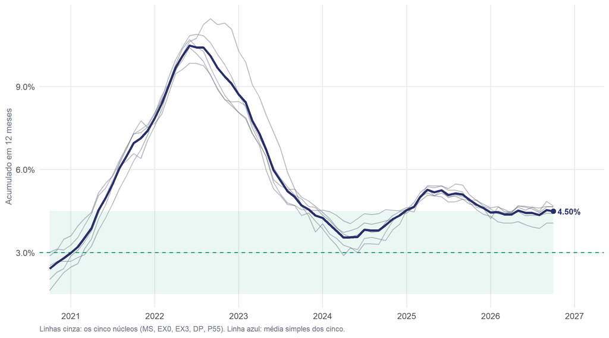

Figura 7: Núcleos de inflação acumulados em 12 meses, frente à meta e à banda

Tabela 2: Núcleos de inflação — out/2026

| Núcleo | Medida | Variação (% a.m.) | Acumulado 12m (%) |
| --- | --- | --- | --- |
| DP | Dupla ponderação | 0.19 | 4.07 |
| EX0 | Exclusão EX0 | 0.10 | 4.68 |
| EX3 | Exclusão EX3 | 0.26 | 4.67 |
| MS | Médias aparadas com suavização | 0.27 | 4.41 |
| P55 | Percentil 55 | 0.27 | 4.66 |
| **Média dos núcleos** | Média simples dos cinco | 0.22 | 4.50 |

Em out/2026, a média dos cinco núcleos ficou em **0.22%**, ante 0.36% em set/2026. No acumulado em 12 meses, a média está em **4.50%**, contra 4.63% do índice cheio.

A comparação entre as duas é o teste decisivo de qualquer leitura mensal. Quando o índice cheio vem abaixo dos núcleos, o alívio está concentrado em itens voláteis ou administrados e tende a não se sustentar. Quando os núcleos cedem junto com o cheio, a desinflação é de fato disseminada — e é esse o sinal que o Copom precisa ver antes de mudar de postura. A faixa verde no gráfico reproduz a banda de tolerância da meta, permitindo avaliar não só a direção dos núcleos, mas a distância que ainda os separa do alvo.

## 9 Natureza dos Preços

Duas aberturas adicionais ajudam a entender *que tipo* de preço está se movendo. A primeira classifica os bens pela durabilidade e isola os serviços; a segunda separa o que é formado em mercado do que é fixado por contrato ou regulação.

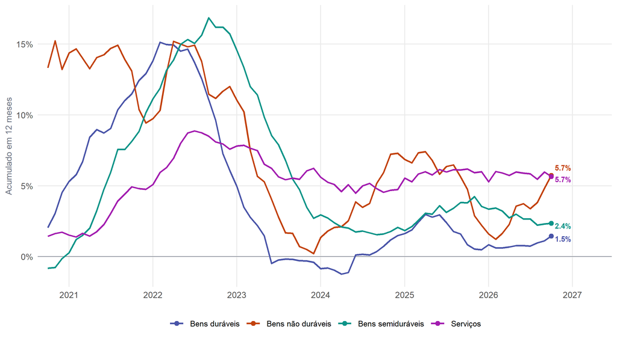

Figura 8: IPCA por natureza do bem — acumulado em 12 meses

Em out/2026, os **serviços** variaram **0.11%** (contra 0.61% em set/2026), acumulando 5.65% em 12 meses. Os bens não duráveis variaram 0.89%, os semiduráveis 0.38% e os duráveis -0.09%.

Serviços são o componente mais inercial do índice: dependem de salário, reajustam-se por contrato anual e reagem com defasagem longa à política monetária. Por isso, sua trajetória em 12 meses é o melhor termômetro do estado do mercado de trabalho dentro da inflação. Bens duráveis, no extremo oposto, respondem a câmbio, crédito e estoque — e costumam ser os primeiros a desinflacionar quando os juros sobem.

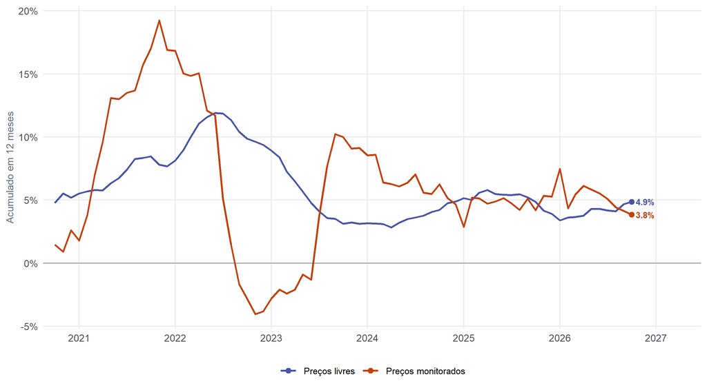

Figura 9: Preços livres e monitorados — acumulado em 12 meses

Os **preços livres** variaram 0.35% no mês (4.87% em 12 meses) e os **monitorados**, -0.44% (3.84% em 12 meses). Monitorados são os preços que não se formam livremente no mercado — energia elétrica, combustíveis, planos de saúde, transporte público, taxas públicas. Respondem a reajuste regulatório, bandeira tarifária e política de preços, não a demanda. Um mês em que o índice cheio desacelera por conta dos monitorados diz pouco sobre pressão inflacionária subjacente: diz apenas que houve decisão administrativa favorável.

## 10 Difusão

O índice de difusão mede a proporção dos subitens do IPCA que registraram alta no mês. É o complemento natural dos núcleos: enquanto estes perguntam *quanto* a inflação persistente está rodando, a difusão pergunta *quão espalhada* ela está.

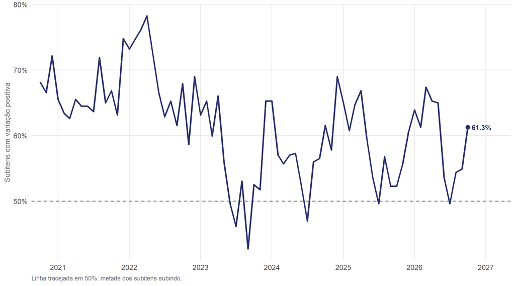

Figura 10: Índice de difusão do IPCA — proporção de subitens em alta

Em out/2026, a difusão ficou em **61.3%**, ante 54.9% em set/2026.

A combinação entre difusão e índice cheio é o que dá o diagnóstico. Índice baixo com difusão alta é o caso mais traiçoeiro: a maioria dos preços está subindo, e o resultado benigno veio de poucos itens de peso grande em forte queda — tipicamente energia ou combustível. É um alívio que não se repete, e que convive com pressão disseminada por baixo. O inverso — índice alto com difusão baixa — indica choque concentrado, de reversão mais provável.

## 11 Surpresa Frente ao Focus

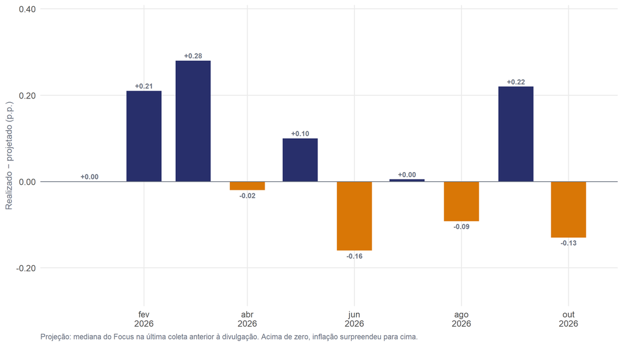

Figura 11: Surpresa inflacionária: IPCA realizado menos a mediana projetada no Focus

Em out/2026, o IPCA veio em **0.14%**, contra mediana projetada de **0.27%** pelas 139 instituições que responderam ao Focus na última coleta anterior à divulgação (06/11/2026). A surpresa foi de **-0.13 p.p.**.

Nenhuma divulgação do IBGE responde à pergunta que o mercado de fato faz: o número veio acima ou abaixo do esperado? A surpresa inflacionária — a diferença entre o realizado e a mediana do Focus coletada imediatamente antes da divulgação — é o que move curva de juros e revisão de projeção no dia do anúncio. Um IPCA de 0,40% pode ser notícia boa, se o mercado esperava 0,55%, e ruim, se esperava 0,25%.

A sequência de surpresas também informa sobre a qualidade das projeções correntes. Erros sistemáticos na mesma direção, mês após mês, indicam que o mercado ainda não incorporou alguma mudança estrutural — de política tarifária, de repasse cambial ou de dinâmica salarial.

## 12 IPCA pelo Brasil

O IPCA nacional é a média ponderada de 16 áreas de pesquisa: 10 regiões metropolitanas e 6 municípios. A dispersão entre elas separa o que é inflação geral do que é choque local — um reajuste de energia estadual ou de tarifa de ônibus municipal pode mover o índice de uma área inteira sem qualquer significado macroeconômico.

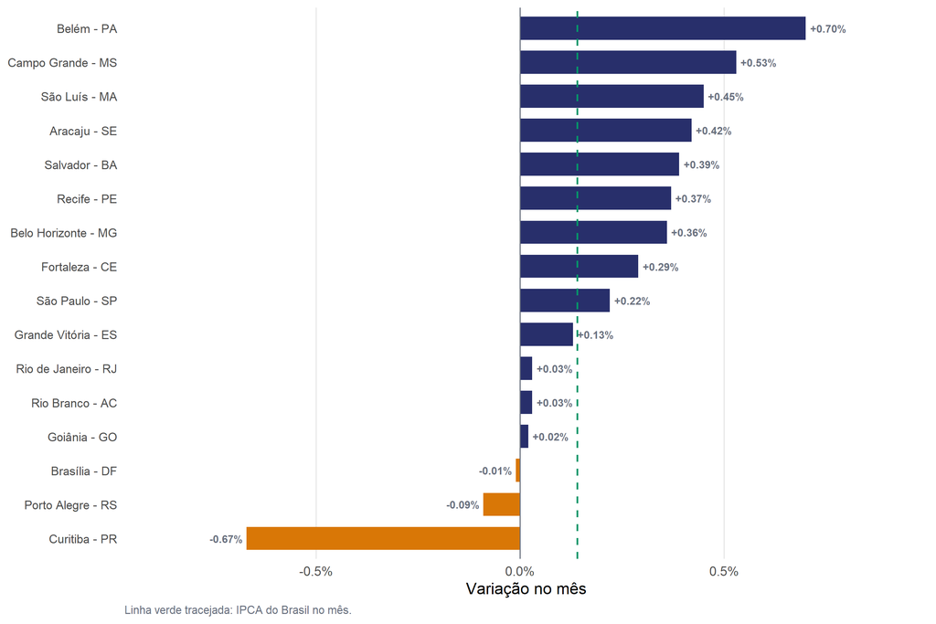

Figura 12: IPCA por área pesquisada — out/2026

Em out/2026, a maior variação foi em **Belém - PA** (0.70%) e a menor, em **Curitiba - PR** (-0.67%) — uma amplitude de **1.37 p.p.** entre os extremos, contra 0.14% do índice nacional.

## 13 INPC: o Contraponto

O **INPC** mede a inflação das famílias com renda de 1 a 5 salários mínimos, enquanto o IPCA cobre de 1 a 40. A cesta do INPC concentra mais peso em alimentação, transporte público e habitação, e menos em serviços pessoais e bens duráveis. A diferença entre os dois índices é, na prática, uma medida de como o mesmo choque de preços atinge de forma desigual faixas de renda distintas.

Tabela 3: IPCA e INPC — out/2026

| Índice | Faixa de renda | Variação (% a.m.) | Acumulado 12m (%) |
| --- | --- | --- | --- |
| IPCA | 1 a 40 salários mínimos | 0.14 | 4.63 |
| INPC | 1 a 5 salários mínimos | 0.22 | 4.49 |

Em out/2026, o INPC variou **0.22%**, contra 0.14% do IPCA, com acumulado em 12 meses de 4.49% ante 4.63%.

Quando o INPC roda acima do IPCA, o choque corrente está concentrado em itens de peso maior na cesta de renda baixa — tipicamente alimentos e tarifas públicas —, e a inflação é regressiva: corrói mais o poder de compra de quem ganha menos. O INPC é também o indexador de referência para o reajuste do salário mínimo e de boa parte dos benefícios previdenciários, o que lhe dá consequência fiscal direta.

## 14 Encerramento

Este relatório consolidou as dimensões do IPCA de **outubro de 2026**:

| Indicador | Valor |
| --- | --- |
| Variação mensal | 0.14% |
| Acumulado no ano | 4.10% |
| Acumulado 12 meses | 4.63% |
| Meta CMN 2026 | 3.00% ± 1,5 p.p. |
| Média dos núcleos (mês) | 0.22% |
| Média dos núcleos (12m) | 4.50% |
| Serviços (mês) | 0.11% |
| Índice de difusão | 61.3% |
| INPC (mês) | 0.22% |
| Maior contribuição do mês | 1.Alimentação e bebidas (+0.22 p.p.) |
| Subitem de maior impacto | Tomate (+0.059 p.p.) |

O acumulado em 12 meses está **acima do teto da banda (4.50%)**. No mês, o índice cheio veio **abaixo** da média dos núcleos, sinal de que o alívio do mês se concentrou em itens voláteis ou administrados e tende a não se sustentar; a difusão em 61.3% mostra a **maioria** dos subitens em alta.

Do ponto de vista operacional, a trajetória do índice cheio reflete o balanço entre os grupos pressionados — especialmente Alimentação e Transportes, mais voláteis e sujeitos a choques de oferta — e os grupos mais inerciais, como Educação e Saúde, que reajustam contratos anualmente. A leitura conjunta dos núcleos, da difusão e da abertura por natureza do preço é o que permite distinguir desinflação efetiva de alívio circunstancial.

**NotaNotas metodológicas e fontes**

**IBGE — API SIDRA, tabela 7060** (pacote `sidrar`)

- IPCA por grupo, subgrupo, item e subitem: variação mensal (variável 63) e peso mensal (variável 66), classificação `c315`. O nível hierárquico é inferido do prefixo numérico do rótulo (1 dígito = grupo, 2 = subgrupo, 4 = item, 7 = subitem).
- IPCA por área: níveis territoriais `n7` (10 regiões metropolitanas) e `n6` (6 municípios).

**BCB — SGS** (pacote `rbcb`)

| Série | Código |
| --- | --- |
| IPCA — variação mensal | 433 |
| Meta de inflação (CMN) | 13521 |
| INPC — variação mensal | 188 |
| Índice de difusão do IPCA | 21379 |
| Núcleo médias aparadas com suavização (MS) | 4466 |
| Núcleo por exclusão EX0 | 11427 |
| Núcleo por exclusão EX3 | 27839 |
| Núcleo dupla ponderação (DP) | 16122 |
| Núcleo percentil 55 (P55) | 28750 |
| Bens não duráveis | 10841 |
| Bens semiduráveis | 10842 |
| Bens duráveis | 10843 |
| Serviços | 10844 |
| Preços livres | 11428 |
| Preços monitorados | 4449 |

Os cinco núcleos são os adotados pelo BCB desde o Estudo Especial 102/2021, que aposentou as medidas EX1, EX2 e as médias aparadas sem suavização.

**BCB — expectativas de mercado** (boletim Focus, via `rbcb`): mediana das projeções para o IPCA mensal, base de cálculo 0 (todas as instituições que responderam nos últimos 30 dias). A projeção usada é a da última coleta anterior à divulgação do resultado.

**Fórmulas**

- Acumulado: $\prod_{i}(1 + x_i/100) - 1$, sem aproximação linear.
- Contribuição: $\text{contrib}_i = \text{variação}_i \times \text{peso}_i / 100$; a soma dos grupos reproduz o índice cheio, com diferenças de arredondamento da API.

**Ressalva sobre a coleta**: a API do SGS trunca respostas muito longas e descarta silenciosamente as observações mais recentes. As séries são baixadas em janelas de 10 anos para evitar que o relatório fique defasado em um mês.

Relatório gerado em 12/11/2026 às 12:45.

**Boletim IPCA** — Mês de referência: outubro de 2026

Elaborado por Raimundo Casé — economista | economistacase@gmail.com

Fontes primárias: IBGE — Instituto Brasileiro de Geografia e Estatística (IPCA, INPC, tabela 7060 do SIDRA) | BCB — Banco Central do Brasil (SGS: metas, núcleos, difusão, classificação de preços; boletim Focus).

*As análises e opiniões expressas neste boletim são de responsabilidade exclusiva do autor e não representam qualquer instituição.*